# PCA and Plasticity

Anoob Prakash

02/06/2021

# Methods

**Adaptive plasticity model**  
- Height was selected as proxy for fitness  
- Absolute plasticity or Plasticity of the trait correlated with fitness to check whether the plasticity is adaptive, maladaptive or neutral

```
Absolute_plasticity or Plasticity <- Height_Growth ~ Abs_P + Region + Abs_P * Region
```

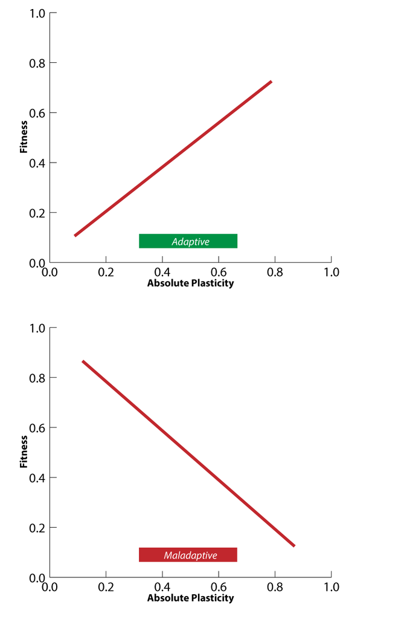

Estimating the adaptive or maladaptive nature of trait plasticity

## notes

gw - growth  
bb - budbreak  
bs - budset  
B - lmer family blups (means)  
P - plasticity value for the trait

## packages

```r
suppressPackageStartupMessages({
  require(ggplot2)
  require(ggpubr)
  require(wesanderson)
  require(factoextra)
  require(dplyr)
  require(lmerTest)
  require(tidyverse)
  require(viridis)
  require(cowplot)

  })
```

```r
# setwd("Z:/Anoob/MCMCglmm")

# data
budset_2019 <- read.csv("./trait_data/BudSet_2019.csv")
budset_2020 <- read.csv("./trait_data/BudSet_2020.csv")
budbreak_2020 <- read.csv("./trait_data/BudBreak_2020_cGDD.csv")
heightGrowth_2019 <- read.csv("./trait_data/Growth_2019.csv")
heightGrowth_2020 <- read.csv("./trait_data/Growth_2020.csv")
exome_meta <- read.table("./Exome/RS_Exome_metadata.txt", header = T, sep="\t")

Plasticity <- read.csv("./trait_data/Plasticity.csv", stringsAsFactors = T); Plasticity <- Plasticity[,-1]
Plasticity$Region <- factor(Plasticity$Region, levels=c("Core","Margin","Edge"))

# Region palette
reg_palette <- c("goldenrod2","green2","steelblue")
```

```r
# exome data
exome_meta <- read.table("./Exome/RS_Exome_metadata.txt", sep="\t", header = T)

# climateNA
Population_climateNA <- read.csv("./ClimateNA/Family/PCA_sprucePops.txt", header=T, sep="\t")
colnames(Population_climateNA)[colnames(Population_climateNA)=="PC1_sel"] <- "PC1"

Family_climateNA <- read.csv("./ClimateNA/Family/PCA_spruceFams.txt", header=T, sep="\t")
colnames(Family_climateNA)[colnames(Family_climateNA)=="PC1_sel"] <- "PC1"
```

## Climate data

**Provenance climate**

```r
Provenance_MAT <- read.table("./ClimateNA/Family/PCA_spruceFams.txt", sep="\t", header =  T, stringsAsFactors = T)
selVars<-c('DD_0','DD18','MAR','PAS','MSP','RH','EXT','CMD','TD','eFFP','current_30arcsec_annualPET')
```

**Garden climate**

```r
Garden_clim <- read.table("./ClimateNA/climNA_gardens_2019-20.txt", header=T)
Garden_clim
```

```
##   garden year MSP DD_0  DD5 DD18 PAS eFFP RH   TD CMD  MAR  EXT       PET
## 1     MD 2019 469  341 2649  368  94  297 66 25.4 212 15.2 36.4  866.3545
## 2     MD 2020 492  224 2548  362  44  299 67 23.7 131 14.8 36.4  872.7068
## 3     NC 2019 478   55 3873  803   5  324 64 20.4 277 17.1 37.7 1147.0480
## 4     NC 2020 723   52 3747  698   4  321 66 20.9 166 16.2 37.8 1094.4220
## 5     VT 2019 471  678 2451  407 172  293 67 31.9 147 13.9 39.6  746.0178
## 6     VT 2020 403  385 2633  483  74  294 67 28.8 226 14.2 38.9  793.8243
```

```r
selVars1 <- c('DD_0','DD18','MAR','PAS','MSP','RH','EXT','CMD','TD','eFFP','PET')
```

# PCA

```r
# create ID for provenance (family level)
identity <- Provenance_MAT[,(1:2)]
colnames(exome_meta)[1] <- "Population"
fam_id <- right_join(identity,exome_meta)
fam_id$Region <- factor(fam_id$Region,levels=c("C","M","E"))
fam_id$Region <- plyr::revalue(fam_id$Region, c("C"="Core","M"="Margin","E"="Edge"))

# selected clim of provenance
data_p2 <-Provenance_MAT[,selVars]
colnames(data_p2)[11] <- "PET"
```

```r
# create ID for garden means
# garden_identity <- Garden_climateNA1[,1]

# create ID for garden
garden_identity <- Garden_clim[,1:2]

# selected clim of gardens
data_p1 <- Garden_clim[,selVars1]
```

```r
# combined ID
head(fam_id)
```

```
##   Population Family Tree State Region     Date Latitude Longitude Elevation
## 1         AB  AB_05    5    TN   Edge  9002016 35.55297  83.49438      1812
## 2         AB  AB_08    8    TN   Edge  9002016 35.55212  83.49259      1785
## 3         AB  AB_12   12    TN   Edge  9002016 35.53890  83.49463      1750
## 4         AB  AB_16   16    TN   Edge  9002016 35.53882  83.49534      1738
## 5         AB  AB_18   18    TN   Edge  9002016 35.53945  83.49375      1769
## 6        ALB ALB_01    1    ME   Core 11112017 44.30670  70.84019       455
##    DBH
## 1 57.7
## 2 44.3
## 3 36.8
## 4 44.0
## 5 68.2
## 6 28.1
```

```r
head(garden_identity)
```

```
##   garden year
## 1     MD 2019
## 2     MD 2020
## 3     NC 2019
## 4     NC 2020
## 5     VT 2019
## 6     VT 2020
```

```r
fam_id <- fam_id[,c("Population","Family","Region")]
fam_id$Garden <- NA
fam_id$Year <- NA

garden_id <- garden_identity
garden_id$Population <- NA
garden_id$Family <- NA
garden_id$Region <- NA
colnames(garden_id)[1] <- "Garden"
colnames(garden_id)[2] <- "Year"
garden_id <- garden_id[,c("Population","Family","Region","Garden","Year")]

id_c <- rbind(garden_id,fam_id)

# combined data
data_c <- rbind(data_p1,data_p2)

# combined PCA
data_pca <- prcomp(data_c,scale. = T)

# Extract PC axes for plotting
PCAvalues <- data.frame(Garden = id_c$Garden, Year = id_c$Year,
                        Population = id_c$Population, Family = id_c$Family, Region = id_c$Region,
                        data_pca$x)
PCAvalues$Year <- as.factor(PCAvalues$Year)
PCAvalues[!is.na(PCAvalues$Garden),"Group"] <- PCAvalues[!is.na(PCAvalues$Garden),"Garden"]

PCAvalues[!is.na(PCAvalues$Region),"Group"] <- PCAvalues[!is.na(PCAvalues$Region),"Region"]
PCAvalues$Group <- as.factor(PCAvalues$Group)

# Extract loadings of the variables
PCAloadings <- data.frame(Variables = rownames(data_pca$rotation), data_pca$rotation)

# write.csv(PCAvalues, row.names = F, "./trait_data/PCA/PCA_score.csv")
# write.csv(PCAloadings, row.names = F, "./trait_data/PCA/PCA_loadings.csv")
```

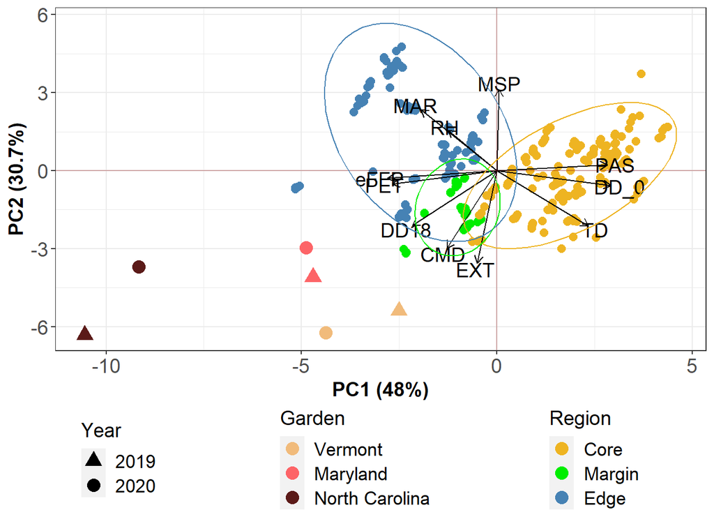

```r
# full plot
full_p <- ggplot(PCAvalues[!is.na(PCAvalues$Region),], aes(x = PC1, y = PC2)) +


  # Provenance data
  geom_point(aes(color=Group),  size=4, pch = 20) +

  # add loadings
  geom_segment(data = PCAloadings, aes(x = 0, y = 0, xend = (PC1*7),
     yend = (PC2*7)), arrow = arrow(length = unit(1/2, "picas")),
     color = "black") +

  annotate("text", x = (PCAloadings$PC1*7.5), y = (PCAloadings$PC2*7.5),
     label = PCAloadings$Variables, size =5) +
                scale_color_manual(values = c(
                                "Core" = "goldenrod2",
                                "Margin" = "green2",
                                "Edge" = "steelblue",
                                "VT" = "#F1BB7B",
                                "NC"="#5B1A18",
                                "MD"="#FD6467"),
                                breaks = c("Core","Margin","Edge","VT","MD","NC"),
                                labels = c("Core","Margin","Edge","Vermont", "Maryland", "North Carolina")) +
  # Garden data
  geom_point(data = PCAvalues[!is.na(PCAvalues$Garden),],
             aes(x = PC1, y = PC2,
                 shape=Year,
                 color=Group), size=4) +

  scale_shape_manual(values = c('2019' = 17, '2020' = 16)) +

  labs(x = "PC1 (48%)", y = "PC2 (30.7%)") +
  theme_bw() +
  theme(legend.position='none',
        axis.text=element_text(size=14),
        axis.title=element_text(size=14,face="bold"),
        legend.title = element_text(color = "black", size = 14),
        legend.text = element_text(color = "black", size = 13)) +
  geom_vline(xintercept = 0, col="darkred", alpha=0.3)+
  geom_hline(yintercept = 0, col="darkred", alpha=0.3) +
  stat_ellipse(
  mapping = aes(PC1, PC2, color = Region),
  data = PCAvalues[!is.na(PCAvalues$Region),],
  geom = "path",
  position = "identity",
  type = "t",
  level = 0.95,
  segments = 51,
  na.rm = FALSE,
  show.legend = NA,
  inherit.aes = TRUE)

# create legend for garden
garden_legend_1 <- ggplot(data = PCAvalues[!is.na(PCAvalues$Garden),]) +
                 geom_point(aes(x = PC1, y = PC2,
                                 shape=Year), size=4) +
                 scale_shape_manual(values = c('2019' = 17, '2020' = 16)) +

                theme(axis.text=element_text(size=14),
                     axis.title=element_text(size=14,face="bold"),
                     legend.title = element_text(color = "black", size = 14),
                     legend.text = element_text(color = "black", size = 13))


garden_legend_2 <- ggplot(data = PCAvalues[!is.na(PCAvalues$Garden),]) +
                 geom_point(aes(x = PC1, y = PC2,

                                 color=Group), size=4) +
                 scale_color_manual(values = c( "VT" = "#F1BB7B",
                                                "NC"="#5B1A18",
                                                "MD"="#FD6467"),
                                                name = "Garden",
                                                breaks = c("VT","MD","NC"),
                                                labels = c("Vermont", "Maryland", "North Carolina")) +
                theme(axis.text=element_text(size=14),
                     axis.title=element_text(size=14,face="bold"),
                     legend.title = element_text(color = "black", size = 14),
                     legend.text = element_text(color = "black", size = 13))



# create legend for Region
region_legend <- ggplot(data = PCAvalues[!is.na(PCAvalues$Region),]) +
                 geom_point(aes(x = PC1, y = PC2,
                                color=Group), size=4) +
                 scale_shape_manual(values = c('2019' = 17, '2020' = 16)) +
                 scale_color_manual(values = c(
                                "Core" = "goldenrod2",
                                "Margin" = "green2",
                                "Edge" = "steelblue"),
                                name = "Region",
                                breaks = c("Core","Margin","Edge"),
                                labels = c("Core","Margin","Edge")) +
                theme(axis.text=element_text(size=14),
                     axis.title=element_text(size=14,face="bold"),
                     legend.title = element_text(color = "black", size = 14),
                     legend.text = element_text(color = "black", size = 13))


cowplot::plot_grid(
  full_p
  , cowplot::plot_grid(
    get_legend(garden_legend_1),
    get_legend(garden_legend_2)
    , get_legend(region_legend)
    , nrow = 1
  )
  , nrow = 2
  , rel_heights = c(8,2)
)
```

# Plasticity vs PC1

## Plasticity vs PC1 Models

### Budset 2019

```r
# budset 2019
budset2019_PC1_mod1 <- lmer(BudSet_2019 ~ PC1 + (1|Population), data=Plasticity[!is.na(Plasticity$BudSet_2019),])

anova(budset2019_PC1_mod1)
```

```
## Type III Analysis of Variance Table with Satterthwaite's method
##      Sum Sq Mean Sq NumDF  DenDF F value Pr(>F)
## PC1 0.03176 0.03176     1 61.243  0.0543 0.8165
```

```r
summary(budset2019_PC1_mod1)
```

```
## Linear mixed model fit by REML. t-tests use Satterthwaite's method [
## lmerModLmerTest]
## Formula: BudSet_2019 ~ PC1 + (1 | Population)
##    Data: Plasticity[!is.na(Plasticity$BudSet_2019), ]
##
## REML criterion at convergence: 807.8
##
## Scaled residuals:
##      Min       1Q   Median       3Q      Max
## -2.50530 -0.69399  0.02162  0.64177  3.09669
##
## Random effects:
##  Groups     Name        Variance Std.Dev.
##  Population (Intercept) 0.07226  0.2688
##  Residual               0.58483  0.7647
## Number of obs: 334, groups:  Population, 65
##
## Fixed effects:
##             Estimate Std. Error       df t value Pr(>|t|)
## (Intercept)  3.16682    0.05403 58.98503  58.615   <2e-16 ***
## PC1         -0.00589    0.02528 61.24270  -0.233    0.817
## ---
## Signif. codes:  0 '***' 0.001 '**' 0.01 '*' 0.05 '.' 0.1 ' ' 1
##
## Correlation of Fixed Effects:
##     (Intr)
## PC1 -0.025
```

### Budset 2020

```r
# budset 2020
budset2020_PC1_mod1 <- lmer(BudSet_2020 ~ PC1 + (1|Population), data=Plasticity[!is.na(Plasticity$BudSet_2020),])

anova(budset2020_PC1_mod1)
```

```
## Type III Analysis of Variance Table with Satterthwaite's method
##       Sum Sq  Mean Sq NumDF  DenDF F value Pr(>F)
## PC1 0.012373 0.012373     1 60.461  0.0968 0.7568
```

```r
summary(budset2020_PC1_mod1)
```

```
## Linear mixed model fit by REML. t-tests use Satterthwaite's method [
## lmerModLmerTest]
## Formula: BudSet_2020 ~ PC1 + (1 | Population)
##    Data: Plasticity[!is.na(Plasticity$BudSet_2020), ]
##
## REML criterion at convergence: 282.1
##
## Scaled residuals:
##     Min      1Q  Median      3Q     Max
## -2.9419 -0.6652  0.0111  0.7081  2.8398
##
## Random effects:
##  Groups     Name        Variance Std.Dev.
##  Population (Intercept) 0.004167 0.06455
##  Residual               0.127860 0.35758
## Number of obs: 334, groups:  Population, 65
##
## Fixed effects:
##              Estimate Std. Error        df t value Pr(>|t|)
## (Intercept)  5.832691   0.021250 57.985915 274.485   <2e-16 ***
## PC1         -0.003103   0.009974 60.461382  -0.311    0.757
## ---
## Signif. codes:  0 '***' 0.001 '**' 0.01 '*' 0.05 '.' 0.1 ' ' 1
##
## Correlation of Fixed Effects:
##     (Intr)
## PC1 -0.028
```

### Budbreak 2020

```r
# budbreak 2020
budbreak2020_PC1_mod1 <- lmer(BudBreak_cGDD ~ PC1 + (1|Population), data=Plasticity[!is.na(Plasticity$BudBreak_cGDD),])

anova(budbreak2020_PC1_mod1)
```

```
## Type III Analysis of Variance Table with Satterthwaite's method
##     Sum Sq Mean Sq NumDF  DenDF F value    Pr(>F)
## PC1 560.27  560.27     1 66.249  33.366 2.226e-07 ***
## ---
## Signif. codes:  0 '***' 0.001 '**' 0.01 '*' 0.05 '.' 0.1 ' ' 1
```

```r
summary(budbreak2020_PC1_mod1)
```

```
## Linear mixed model fit by REML. t-tests use Satterthwaite's method [
## lmerModLmerTest]
## Formula: BudBreak_cGDD ~ PC1 + (1 | Population)
##    Data: Plasticity[!is.na(Plasticity$BudBreak_cGDD), ]
##
## REML criterion at convergence: 1954.8
##
## Scaled residuals:
##     Min      1Q  Median      3Q     Max
## -3.6209 -0.5602  0.0713  0.6796  1.8507
##
## Random effects:
##  Groups     Name        Variance Std.Dev.
##  Population (Intercept)  5.757   2.399
##  Residual               16.792   4.098
## Number of obs: 334, groups:  Population, 65
##
## Fixed effects:
##             Estimate Std. Error      df t value Pr(>|t|)
## (Intercept)  28.0225     0.3764 62.9877  74.456  < 2e-16 ***
## PC1          -1.0115     0.1751 66.2493  -5.776 2.23e-07 ***
## ---
## Signif. codes:  0 '***' 0.001 '**' 0.01 '*' 0.05 '.' 0.1 ' ' 1
##
## Correlation of Fixed Effects:
##     (Intr)
## PC1 -0.021
```

### Growth 2019

```r
# growth 2019
growth2019_PC1_mod1 <- lmer(Growth_2019 ~ PC1 + (1|Population), data=Plasticity[!is.na(Plasticity$Growth_2019),])

anova(growth2019_PC1_mod1)
```

```
## Type III Analysis of Variance Table with Satterthwaite's method
##      Sum Sq Mean Sq NumDF DenDF F value    Pr(>F)
## PC1 0.44243 0.44243     1 68.98  60.936 4.529e-11 ***
## ---
## Signif. codes:  0 '***' 0.001 '**' 0.01 '*' 0.05 '.' 0.1 ' ' 1
```

```r
summary(growth2019_PC1_mod1)
```

```
## Linear mixed model fit by REML. t-tests use Satterthwaite's method [
## lmerModLmerTest]
## Formula: Growth_2019 ~ PC1 + (1 | Population)
##    Data: Plasticity[!is.na(Plasticity$Growth_2019), ]
##
## REML criterion at convergence: -628.1
##
## Scaled residuals:
##     Min      1Q  Median      3Q     Max
## -2.8264 -0.6755 -0.1184  0.6271  3.4848
##
## Random effects:
##  Groups     Name        Variance Std.Dev.
##  Population (Intercept) 0.001847 0.04298
##  Residual               0.007261 0.08521
## Number of obs: 334, groups:  Population, 65
##
## Fixed effects:
##              Estimate Std. Error        df t value Pr(>|t|)
## (Intercept)  0.164158   0.007156 66.049367  22.939  < 2e-16 ***
## PC1         -0.026047   0.003337 68.980217  -7.806 4.53e-11 ***
## ---
## Signif. codes:  0 '***' 0.001 '**' 0.01 '*' 0.05 '.' 0.1 ' ' 1
##
## Correlation of Fixed Effects:
##     (Intr)
## PC1 -0.022
```

### Growth 2020

```r
# growth 2020
growth2020_PC1_mod1 <- lmer(Growth_2020 ~ PC1 + (1|Population), data=Plasticity[!is.na(Plasticity$Growth_2020),])

anova(growth2020_PC1_mod1)
```

```
## Type III Analysis of Variance Table with Satterthwaite's method
##      Sum Sq Mean Sq NumDF DenDF F value  Pr(>F)
## PC1 0.16999 0.16999     1 67.73  3.5533 0.06372 .
## ---
## Signif. codes:  0 '***' 0.001 '**' 0.01 '*' 0.05 '.' 0.1 ' ' 1
```

```r
summary(growth2020_PC1_mod1)
```

```
## Linear mixed model fit by REML. t-tests use Satterthwaite's method [
## lmerModLmerTest]
## Formula: Growth_2020 ~ PC1 + (1 | Population)
##    Data: Plasticity[!is.na(Plasticity$Growth_2020), ]
##
## REML criterion at convergence: 19
##
## Scaled residuals:
##      Min       1Q   Median       3Q      Max
## -2.89344 -0.47660  0.07766  0.61271  2.32820
##
## Random effects:
##  Groups     Name        Variance Std.Dev.
##  Population (Intercept) 0.02092  0.1446
##  Residual               0.04784  0.2187
## Number of obs: 334, groups:  Population, 65
##
## Fixed effects:
##             Estimate Std. Error       df t value Pr(>|t|)
## (Intercept)  0.84749    0.02177 63.92545  38.934   <2e-16 ***
## PC1          0.01905    0.01011 67.73023   1.885   0.0637 .
## ---
## Signif. codes:  0 '***' 0.001 '**' 0.01 '*' 0.05 '.' 0.1 ' ' 1
##
## Correlation of Fixed Effects:
##     (Intr)
## PC1 -0.019
```

## Plasticity vs PC1 Viz

### Phenology

```r
pheno_plastic <- subset(Plasticity, select=-c(BudBreak_DOY,Growth_2019,Growth_2020)) # growth_2019,growth_2020
colnames(pheno_plastic)[colnames(pheno_plastic)=="BudBreak_cGDD"] <- "BudBreak_2020"



Plasticity_pheno <- pheno_plastic %>% tidyr::pivot_longer(cols=c("BudBreak_2020":"BudSet_2020"),
                                                           names_to = "Traits",
                                                           values_to = "value")
Plasticity_pheno$TraitType <- ifelse(startsWith(Plasticity_pheno$Traits, "BudSet"), "BudSet", "BudBreak")
Plasticity_pheno$Year <- ifelse(endsWith(Plasticity_pheno$Traits, "2020"), "2020", "2019")
# Plasticity_pheno <- dplyr::rename(Plasticity_pheno, PC1 = PC1_sel)

# Population means
Provenance_pop <- read.table("./ClimateNA/Family/PCA_sprucePops.txt", sep="\t", header =  T, stringsAsFactors = T)
Provenance_pop <- subset(Provenance_pop, select=c(Population,PC1_sel,MAT))
Provenance_pop <- dplyr::rename(Provenance_pop,c(PC1_pop=PC1_sel,MAT_pop=MAT))

# Add population means to the main dataframe
Plasticity_pheno <- left_join(Plasticity_pheno,Provenance_pop)
```

```r
# combined
Phenology <-  ggplot(data=Plasticity_pheno,
                   mapping = aes(x=PC1,y=abs(value),group=Traits)) +
                   geom_smooth(method='lm', formula= y~x, show.legend = FALSE, col="darkred") + theme_minimal() +
                   geom_point(aes(colour = Region, shape=TraitType), size = 4, alpha = .4) +
              scale_color_manual(values = c("Core" = "goldenrod2","Margin"="green2","Edge"="steelblue")) +
              labs(x = "PC1", y = "Plasticity (CV)") +
              theme_bw(base_size = 11, base_family = "Times") +
              theme(axis.text=element_text(size=14),
                    axis.title=element_text(size=18),
                    panel.background = element_blank(),
                    legend.background = element_blank(),
                    panel.grid = element_blank(),
                    plot.background = element_blank(),
                    legend.text=element_text(size=rel(.8)),
                    strip.text = element_text(size=30)) +
              facet_grid(.~Year) +
                    theme(strip.text.x = element_text(size = 30))

# create legend
test1 <- ggplot(data=Plasticity_pheno,
       mapping = aes(x=PC1,y=abs(value),group=Traits)) +
       geom_smooth(method='lm', formula= y~x, show.legend = FALSE, col="darkred") + theme_minimal() +
       geom_point(aes(colour = Region, shape=TraitType), size = 3, alpha = 1) +
  scale_color_manual(values = c("Core" = "goldenrod2","Margin"="green2","Edge"="steelblue")) +
  labs(x = "PC1", y = "Absolute Plasticity") +
  scale_color_manual(values = c("Core" = "goldenrod2","Margin"="green2","Edge"="steelblue")) +
      theme_bw() + theme(axis.text=element_text(size=10),
                                                 axis.title=element_text(size=12),
                                                 legend.position = "right",
                                                 legend.title=element_text(size=21),
                                                 legend.text=element_text(size=20),
                                                 plot.background = element_blank(),
                                                 panel.grid.major = element_blank(),
                                                 panel.grid.minor = element_blank(),
                                                 panel.background = element_blank(),
                                                 plot.title = element_blank()) +
  guides(color = guide_legend(override.aes = list(size = 8)))
```

[output not shown]

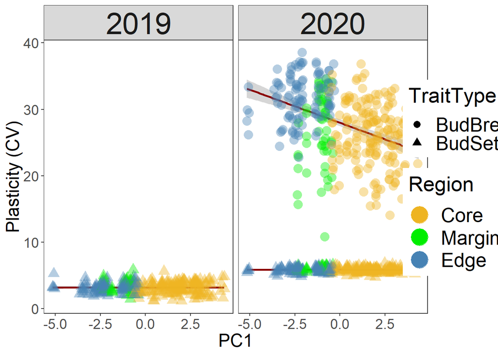

```r
legend_ba <- get_legend(test1 + theme(legend.position="right"))

# final
cowplot::plot_grid(Phenology+ theme(legend.position="none"), legend_ba, ncol = 2, rel_widths = c(1,.15))
```

### Growth

```r
growth_plastic <- subset(Plasticity, select=-c(BudBreak_DOY,BudBreak_cGDD,BudSet_2020,BudSet_2019));


growth_plastic <- growth_plastic %>% tidyr::pivot_longer(cols=c("Growth_2019":"Growth_2020"),
                                                           names_to = "Traits",
                                                           values_to = "value")
growth_plastic$TraitType <- "Growth"
growth_plastic$Year <- ifelse(endsWith(growth_plastic$Traits, "2020"), "2020", "2019")
# growth_plastic <- dplyr::rename(growth_plastic, PC1 = PC1_sel)

# Add population means to the main dataframe
growth_plastic <- left_join(growth_plastic,Provenance_pop)
```

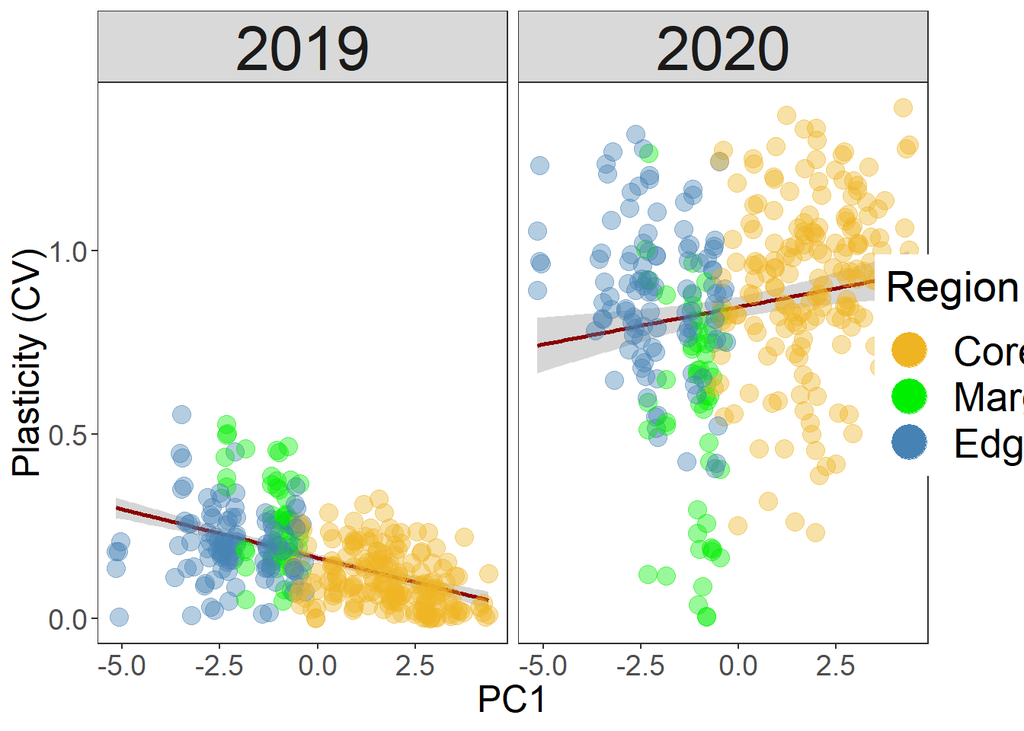

```r
# growth
Growth <- ggplot(data=growth_plastic,
       mapping = aes(x=PC1,y=abs(value),group=Traits)) +
       geom_smooth(method='lm', formula= y~x, show.legend = FALSE, col="darkred") + theme_minimal() +
       geom_point(aes(colour = Region), size = 4, alpha = .4) +
  scale_color_manual(values = c("Core" = "goldenrod2","Margin"="green2","Edge"="steelblue",
                                "growth2019_Plasticity"="darkred", "growth2020_Plasticity"="limegreen")) +
  labs(x = "PC1", y = "Plasticity (CV)") +
  theme_bw(base_size = 11, base_family = "Times") +
  theme(axis.text=element_text(size=14),
        axis.title=element_text(size=18),
        panel.background = element_blank(),
        legend.background = element_blank(),
        panel.grid = element_blank(),
        plot.background = element_blank(),
        legend.text=element_text(size=rel(.8)),
        strip.text = element_text(size=30)) +
  facet_grid(.~Year)

  # create legend
test2 <- ggplot(data=growth_plastic,
       mapping = aes(x=PC1,y=abs(value),group=Traits)) +
       geom_smooth(method='lm', formula= y~x, show.legend = FALSE, col="darkred") + theme_minimal() +
       geom_point(aes(colour = Region), size = 3, alpha = 1) +
  scale_color_manual(values = c("Core" = "goldenrod2","Margin"="green2","Edge"="steelblue")) +
      theme_bw() + theme(axis.text=element_text(size=10),
                                                 axis.title=element_text(size=12),
                                                 legend.position = "right",
                                                 legend.title=element_text(size=21),
                                                 legend.text=element_text(size=20),
                                                 plot.background = element_blank(),
                                                 panel.grid.major = element_blank(),
                                                 panel.grid.minor = element_blank(),
                                                 panel.background = element_blank(),
                                                 plot.title = element_blank()) +
  guides(color = guide_legend(override.aes = list(size = 8)))

legend_bb <- get_legend(test2 + theme(legend.position="right"))

# final
cowplot::plot_grid(Growth+ theme(legend.position="none"), legend_bb, ncol = 2, rel_widths = c(1,.09))
```

### ANOVA

```r
sjPlot::tab_model(budset2019_PC1_mod1, budset2020_PC1_mod1, budbreak2020_PC1_mod1,growth2019_PC1_mod1, growth2020_PC1_mod1,
                   dv.labels = c("Budset 2019", "Budset 2020", "Budbreak 2020", "Growth 2019", "Growth 2020"),
                  string.pred = "Coeffcient",
                  string.ci = "CI (95%)",
                  string.p = "P-Value",
                  p.style = "stars")
```

Budset 2019

Budset 2020

Budbreak 2020

Growth 2019

Growth 2020

Coeffcient

Estimates

CI (95%)

Estimates

CI (95%)

Estimates

CI (95%)

Estimates

CI (95%)

Estimates

CI (95%)

(Intercept)

3.17 ***

3.06 – 3.27

5.83 ***

5.79 – 5.87

28.02 ***

27.28 – 28.76

0.16 ***

0.15 – 0.18

0.85 ***

0.80 – 0.89

PC1

-0.01

-0.06 – 0.04

-0.00

-0.02 – 0.02

-1.01 ***

-1.35 – -0.67

-0.03 ***

-0.03 – -0.02

0.02

-0.00 – 0.04

Random Effects

σ<sup>2</sup>

0.58

0.13

16.79

0.01

0.05

τ<sub>00</sub>

0.07 <sub>Population</sub>

0.00 <sub>Population</sub>

5.76 <sub>Population</sub>

0.00 <sub>Population</sub>

0.02 <sub>Population</sub>

ICC

0.11

0.03

0.26

0.20

0.30

N

65 <sub>Population</sub>

65 <sub>Population</sub>

65 <sub>Population</sub>

65 <sub>Population</sub>

65 <sub>Population</sub>

Observations

334

334

334

334

334

Marginal R<sup>2</sup> / Conditional R<sup>2</sup>

0.000 / 0.110

0.000 / 0.032

0.171 / 0.382

0.252 / 0.404

0.023 / 0.320

- p<0.05 ** p<0.01 *** p<0.001

## Figure for paper

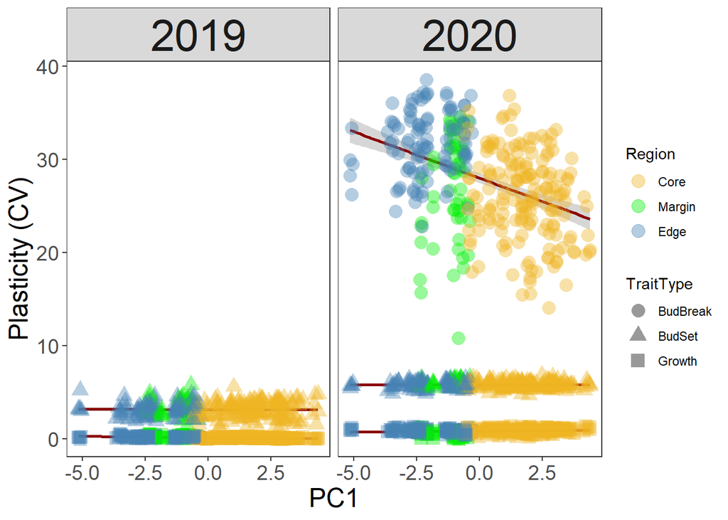

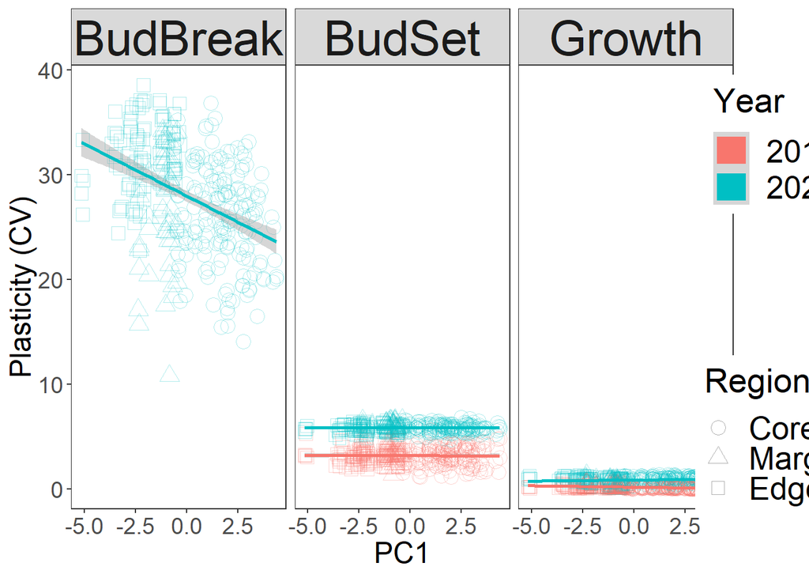

# Plasticity vs Height Growth

## Height growth of 2019

- Means vs Plasticity

### Family data

```r
# blups for height growth
heightGrowth_2019_2 <- heightGrowth_2019
heightGrowth_2019_2 <- heightGrowth_2019_2%>% unite(mBed, Garden, Bed, sep = "_", remove = FALSE)

HeightGrowth_2019_mod <- lmer(Growth ~ Garden + (1|mBed) + (1|Family), heightGrowth_2019_2)

HeightGrowth_2019_blup <- ranef(HeightGrowth_2019_mod)
HeightGrowth_2019_blup <- HeightGrowth_2019_blup$Family
HeightGrowth_2019_blup <- cbind(Family=rownames(HeightGrowth_2019_blup),HeightGrowth_2019_blup)
rownames(HeightGrowth_2019_blup) <- NULL
names(HeightGrowth_2019_blup)[2] <- "Height_Growth"

# plasticity based on height growth
HeightGrowth_2019_blup <- merge(x=HeightGrowth_2019_blup,
                                y=Plasticity[,c("Family","Growth_2019")],
                                by="Family")
# rename plasticity column
colnames(HeightGrowth_2019_blup)[colnames(HeightGrowth_2019_blup)=="Growth_2019"] <- "Plasticity"

# remove NAs
HeightGrowth_2019_blup <- HeightGrowth_2019_blup[!is.na(HeightGrowth_2019_blup$Plasticity),]

# Population column creation
HeightGrowth_2019_blup$Population <- gsub("\\_.*", "", HeightGrowth_2019_blup$Family)

# merge climateNA data
HeightGrowth_2019_blup <- merge(x=HeightGrowth_2019_blup,
                               y=Family_climateNA[,c("Population","PC1","MAT")],
                               by="Population")

# merge Region data
HeightGrowth_2019_blup <- merge(x=HeightGrowth_2019_blup,
                               y=heightGrowth_2019[,c("Population","Region")],
                               by="Population")

# reorder regions
HeightGrowth_2019_blup$Region <- factor(HeightGrowth_2019_blup$Region,levels = c("Core", "Margin", "Edge"))

HeightGrowth_2019_blup <- distinct(HeightGrowth_2019_blup)

HeightGrowth_2019_blup$Abs_P <- abs(HeightGrowth_2019_blup$Plasticity)
```

### Population data

```r
HeightGrowth_2019_blup$Population <- as.factor(HeightGrowth_2019_blup$Population)

HeightGrowth_2019_pop <- HeightGrowth_2019_blup %>%
                            select(Population, Height_Growth, Plasticity, Region) %>%
                            group_by(Population) %>%
                            dplyr::summarise(Height_Growth = mean(Height_Growth), Plasticity = mean(Plasticity))

HeightGrowth_2019_pop <- merge(x=HeightGrowth_2019_pop,
                               y=Population_climateNA[,c("Population","PC1","MAT")],
                               by="Population")

HeightGrowth_2019_pop <- merge(x=HeightGrowth_2019_pop,
                               y=heightGrowth_2019[,c("Population","Region")],
                               by="Population")
# reorder regions
HeightGrowth_2019_pop$Region <- factor(HeightGrowth_2019_pop$Region,levels = c("Core", "Margin", "Edge"))

HeightGrowth_2019_pop <- distinct(HeightGrowth_2019_pop)

HeightGrowth_2019_pop$Abs_P <- abs(HeightGrowth_2019_pop$Plasticity)
```

### Family plot

```r
HeightGrowth_2019_fam_abs_mod <- lm(Height_Growth ~ Abs_P + Region + Abs_P*Region,
                                    data=HeightGrowth_2019_blup)
summary(HeightGrowth_2019_fam_abs_mod)
```

```
##
## Call:
## lm(formula = Height_Growth ~ Abs_P + Region + Abs_P * Region,
##     data = HeightGrowth_2019_blup)
##
## Residuals:
##     Min      1Q  Median      3Q     Max
## -4.5173 -0.0751  0.0890  0.2742  0.7124
##
## Coefficients:
##                    Estimate Std. Error  t value Pr(>|t|)
## (Intercept)        -3.44017    0.03362 -102.320  < 2e-16 ***
## Abs_P              20.84251    0.25121   82.970  < 2e-16 ***
## RegionMargin        0.26170    0.09085    2.881  0.00402 **
## RegionEdge          0.40777    0.06659    6.124 1.11e-09 ***
## Abs_P:RegionMargin -1.17380    0.37479   -3.132  0.00176 **
## Abs_P:RegionEdge   -1.52333    0.35440   -4.298 1.81e-05 ***
## ---
## Signif. codes:  0 '***' 0.001 '**' 0.01 '*' 0.05 '.' 0.1 ' ' 1
##
## Residual standard error: 0.6059 on 1851 degrees of freedom
## Multiple R-squared:  0.9367, Adjusted R-squared:  0.9365
## F-statistic:  5474 on 5 and 1851 DF,  p-value: < 2.2e-16
```

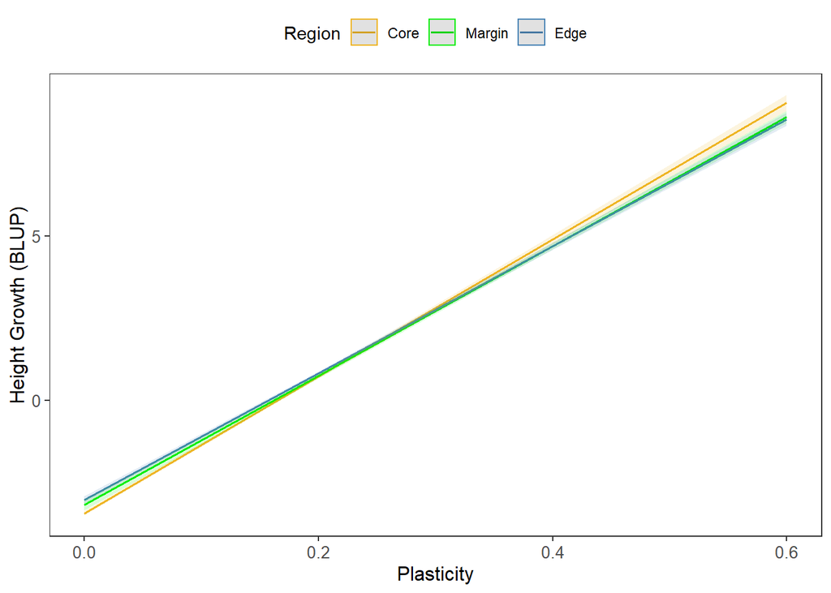

### Population plot

```r
HeightGrowth_2019_pop_abs_mod <- lm(Height_Growth ~ Abs_P + Region + Abs_P*Region,
                                    data=HeightGrowth_2019_pop)
summary(HeightGrowth_2019_pop_abs_mod)
```

```
##
## Call:
## lm(formula = Height_Growth ~ Abs_P + Region + Abs_P * Region,
##     data = HeightGrowth_2019_pop)
##
## Residuals:
##      Min       1Q   Median       3Q      Max
## -0.79780 -0.05818  0.00806  0.12916  0.61914
##
## Coefficients:
##                    Estimate Std. Error t value Pr(>|t|)
## (Intercept)         -4.0053     0.1501 -26.691  < 2e-16 ***
## Abs_P               25.9086     1.3238  19.571  < 2e-16 ***
## RegionMargin         0.8896     0.3405   2.613 0.011382 *
## RegionEdge           1.0275     0.3312   3.103 0.002942 **
## Abs_P:RegionMargin  -6.3872     1.7397  -3.671 0.000521 ***
## Abs_P:RegionEdge    -6.8532     1.9572  -3.502 0.000888 ***
## ---
## Signif. codes:  0 '***' 0.001 '**' 0.01 '*' 0.05 '.' 0.1 ' ' 1
##
## Residual standard error: 0.2934 on 59 degrees of freedom
## Multiple R-squared:  0.9721, Adjusted R-squared:  0.9697
## F-statistic: 410.8 on 5 and 59 DF,  p-value: < 2.2e-16
```

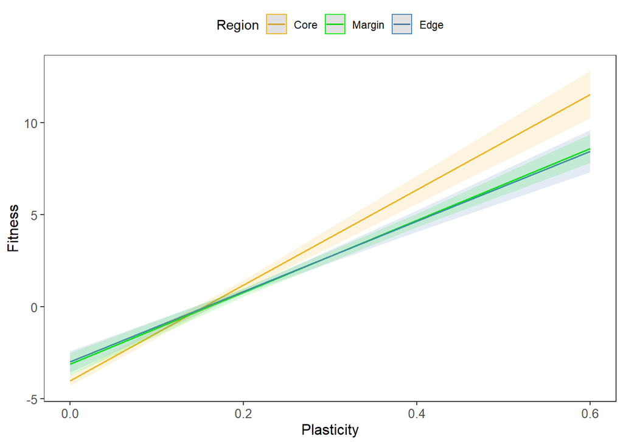

## Height growth of 2020

- Means vs Plasticity

### Family data

```r
# blups for height growth
heightGrowth_2020_2 <- heightGrowth_2020
heightGrowth_2020_2 <- heightGrowth_2020_2%>% unite(mBed, Garden, Bed, sep = "_", remove = FALSE)

HeightGrowth_2020_mod <- lmer(Growth ~ Garden + (1|mBed) + (1|Family), heightGrowth_2020_2)

HeightGrowth_2020_blup <- ranef(HeightGrowth_2020_mod)
HeightGrowth_2020_blup <- HeightGrowth_2020_blup$Family
HeightGrowth_2020_blup <- cbind(Family=rownames(HeightGrowth_2020_blup),HeightGrowth_2020_blup)
rownames(HeightGrowth_2020_blup) <- NULL
names(HeightGrowth_2020_blup)[2] <- "Height_Growth"

# plasticity based on height growth
HeightGrowth_2020_blup <- merge(x=HeightGrowth_2020_blup,
                                y=Plasticity[,c("Family","Growth_2020")],
                                by="Family")
# rename plasticity column
colnames(HeightGrowth_2020_blup)[colnames(HeightGrowth_2020_blup)=="Growth_2020"] <- "Plasticity"

# remove NAs
HeightGrowth_2020_blup <- HeightGrowth_2020_blup[!is.na(HeightGrowth_2020_blup$Plasticity),]

# Population column creation
HeightGrowth_2020_blup$Population <- gsub("\\_.*", "", HeightGrowth_2020_blup$Family)

# merge climateNA data
HeightGrowth_2020_blup <- merge(x=HeightGrowth_2020_blup,
                               y=Family_climateNA[,c("Population","PC1","MAT")],
                               by="Population")

# merge Region data
HeightGrowth_2020_blup <- merge(x=HeightGrowth_2020_blup,
                               y=heightGrowth_2020[,c("Population","Region")],
                               by="Population")
# reorder regions
HeightGrowth_2020_blup$Region <- factor(HeightGrowth_2020_blup$Region,levels = c("Core", "Margin", "Edge"))

HeightGrowth_2020_blup <- distinct(HeightGrowth_2020_blup)

HeightGrowth_2020_blup$Abs_P <- abs(HeightGrowth_2020_blup$Plasticity)
```

### Population data

```r
HeightGrowth_2020_blup$Population <- as.factor(HeightGrowth_2020_blup$Population)

HeightGrowth_2020_pop <- HeightGrowth_2020_blup %>%
                            select(Population, Height_Growth, Plasticity, Region) %>%
                            group_by(Population) %>%
                            dplyr::summarise(Height_Growth = mean(Height_Growth), Plasticity = mean(Plasticity))

HeightGrowth_2020_pop <- merge(x=HeightGrowth_2020_pop,
                               y=Population_climateNA[,c("Population","PC1","MAT")],
                               by="Population")

HeightGrowth_2020_pop <- merge(x=HeightGrowth_2020_pop,
                               y=heightGrowth_2019[,c("Population","Region")],
                               by="Population")
# reorder regions
HeightGrowth_2020_pop$Region <- factor(HeightGrowth_2020_pop$Region,levels = c("Core", "Margin", "Edge"))

HeightGrowth_2020_pop <- distinct(HeightGrowth_2020_pop)

HeightGrowth_2020_pop$Abs_P <- abs(HeightGrowth_2020_pop$Plasticity)
```

### Family plot

```r
HeightGrowth_2020_fam_abs_mod <- lm(Height_Growth ~ Abs_P + Region + Abs_P*Region,
                                    data=HeightGrowth_2020_blup)
summary(HeightGrowth_2020_fam_abs_mod)
```

```
##
## Call:
## lm(formula = Height_Growth ~ Abs_P + Region + Abs_P * Region,
##     data = HeightGrowth_2020_blup)
##
## Residuals:
##     Min      1Q  Median      3Q     Max
## -4.6286 -0.4908 -0.0495  0.3532 15.5621
##
## Coefficients:
##                    Estimate Std. Error t value Pr(>|t|)
## (Intercept)         6.40454    0.22541  28.413  < 2e-16 ***
## Abs_P              -7.89036    0.23892 -33.024  < 2e-16 ***
## RegionMargin       -1.06800    0.31047  -3.440 0.000595 ***
## RegionEdge         -0.06272    0.41411  -0.151 0.879626
## Abs_P:RegionMargin  5.05131    0.41562  12.154  < 2e-16 ***
## Abs_P:RegionEdge    0.03699    0.45338   0.082 0.934984
## ---
## Signif. codes:  0 '***' 0.001 '**' 0.01 '*' 0.05 '.' 0.1 ' ' 1
##
## Residual standard error: 1.791 on 1851 degrees of freedom
## Multiple R-squared:  0.6359, Adjusted R-squared:  0.635
## F-statistic: 646.7 on 5 and 1851 DF,  p-value: < 2.2e-16
```

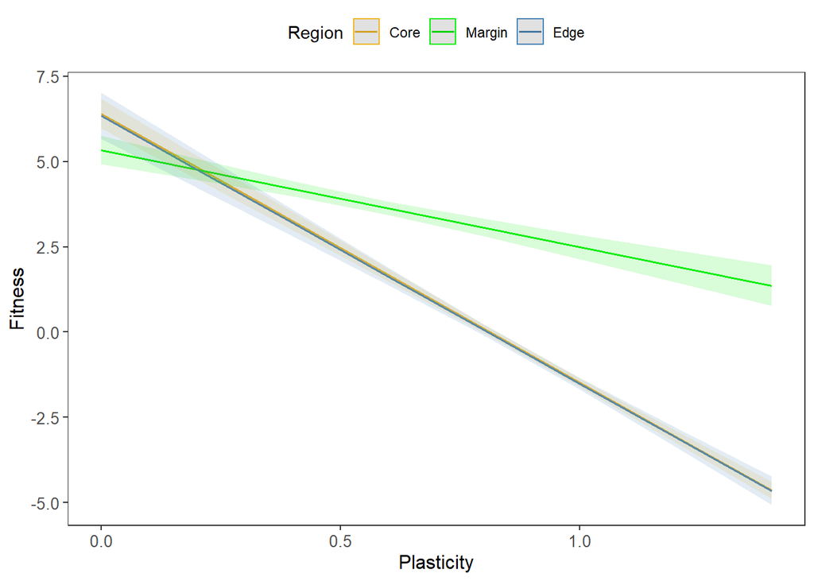

### Population plot

```r
HeightGrowth_2020_pop_abs_mod <- lm(Height_Growth ~ Abs_P + Region + Abs_P*Region,
                                    data=HeightGrowth_2020_pop)
summary(HeightGrowth_2020_pop_abs_mod)
```

```
##
## Call:
## lm(formula = Height_Growth ~ Abs_P + Region + Abs_P * Region,
##     data = HeightGrowth_2020_pop)
##
## Residuals:
##     Min      1Q  Median      3Q     Max
## -3.8747 -0.1743 -0.0479  0.1071  9.1229
##
## Coefficients:
##                    Estimate Std. Error t value Pr(>|t|)
## (Intercept)          6.4983     1.6483   3.942 0.000217 ***
## Abs_P               -7.9608     1.7941  -4.437 4.04e-05 ***
## RegionMargin        -3.3675     2.4740  -1.361 0.178649
## RegionEdge          -0.3484     2.8208  -0.124 0.902120
## Abs_P:RegionMargin   8.6277     3.6101   2.390 0.020066 *
## Abs_P:RegionEdge     0.3684     3.1435   0.117 0.907113
## ---
## Signif. codes:  0 '***' 0.001 '**' 0.01 '*' 0.05 '.' 0.1 ' ' 1
##
## Residual standard error: 1.393 on 59 degrees of freedom
## Multiple R-squared:  0.6384, Adjusted R-squared:  0.6078
## F-statistic: 20.83 on 5 and 59 DF,  p-value: 6.245e-12
```

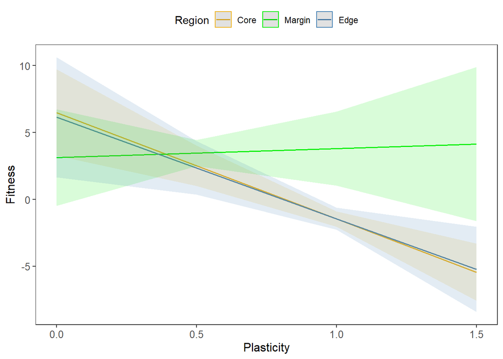

## Budbreak 2020 Plasticity

### Family data

```r
# blups for height growth
heightGrowth_2020_2 <- heightGrowth_2020
heightGrowth_2020_2 <- heightGrowth_2020_2 %>% unite(mBed, Garden, Bed, sep = "_", remove = FALSE)

HeightGrowth_2020_mod <- lmer(Growth ~ Garden + (1|mBed) + (1|Family), heightGrowth_2020_2)

HeightGrowth_2020_blup <- ranef(HeightGrowth_2020_mod)
HeightGrowth_2020_blup <- HeightGrowth_2020_blup$Family
HeightGrowth_2020_blup <- cbind(Family=rownames(HeightGrowth_2020_blup),HeightGrowth_2020_blup)
rownames(HeightGrowth_2020_blup) <- NULL
names(HeightGrowth_2020_blup)[2] <- "Height_Growth"

# plasticity based on budbreak 2020
gw_20_B_bb_20_P <- merge(x=HeightGrowth_2020_blup,
                         y=Plasticity[,c("Family","BudBreak_cGDD")],
                         by="Family")
# rename plasticity column if needed
colnames(gw_20_B_bb_20_P)[colnames(gw_20_B_bb_20_P) == "BudBreak_cGDD"] <- "BudBreak2020_Plasticity"

# remove NAs
gw_20_B_bb_20_P <- gw_20_B_bb_20_P[!is.na(gw_20_B_bb_20_P$BudBreak2020_Plasticity),]

# Population column creation
gw_20_B_bb_20_P$Population <- gsub("\\_.*", "", gw_20_B_bb_20_P$Family)

# merge climateNA data
gw_20_B_bb_20_P <- merge(x=gw_20_B_bb_20_P,
                               y=Family_climateNA[,c("Population","PC1","MAT")],
                               by="Population")

# merge Region data
gw_20_B_bb_20_P <- merge(x=gw_20_B_bb_20_P,
                               y=heightGrowth_2020[,c("Population","Region")],
                               by="Population")
# reorder regions
gw_20_B_bb_20_P$Region <- factor(gw_20_B_bb_20_P$Region,levels = c("Core", "Margin", "Edge"))


gw_20_B_bb_20_P <- distinct(gw_20_B_bb_20_P)

gw_20_B_bb_20_P$Abs_P <- abs(gw_20_B_bb_20_P$BudBreak2020_Plasticity)
```